# COMPSCIX 415.2 Homework 2

# 3.4.2.4

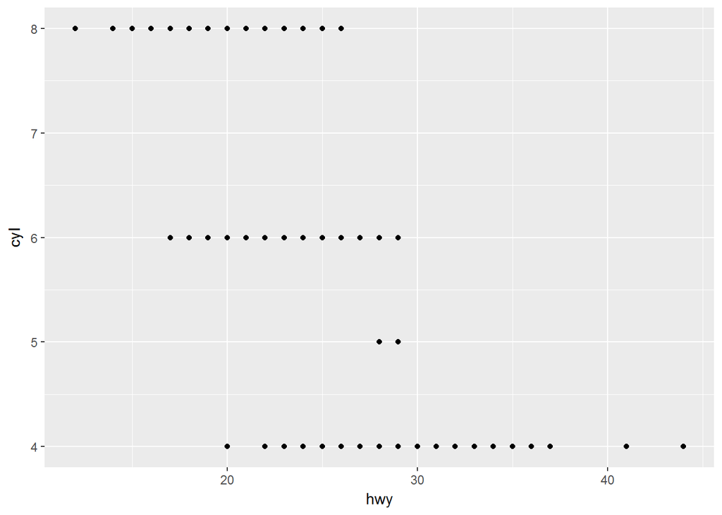

```r
ggplot(data = mpg) + geom_point(mapping = aes(x = hwy, y = cyl))
```

# 3.4.2.5

This plot isn’t helpful because it doesn’t provide this information in a useful way. A histogram would be better suited to compare and analyze these two variables.

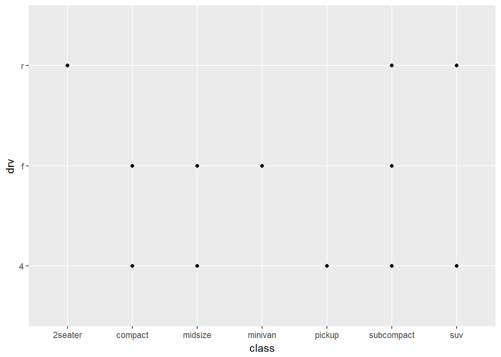

```r
ggplot(data = mpg) + geom_point(mapping = aes(x = class, y = drv))
```

# 3.3.1.1

The points aren’t blue because the “color” level is inside the same function as the coordinates. Coordinates are their own aes() function, and in order to manually set the color as “blue” it should look like: ggplot(data = mpg) + geom_point(mapping = aes(x = displ, y = hwy), color = “blue”)

# 3.3.1.2

The categorical variables are: manufacturer, model, cyl, trans, drv, fl, class. The continuous variables are: displ, year, cty, hwy. You can view this information in the help pane in RStudio after typing mpg? in the console pane.

# 3.3.1.3

These aesthetics work much better for categorical variables (see final example below for this question)

color=year

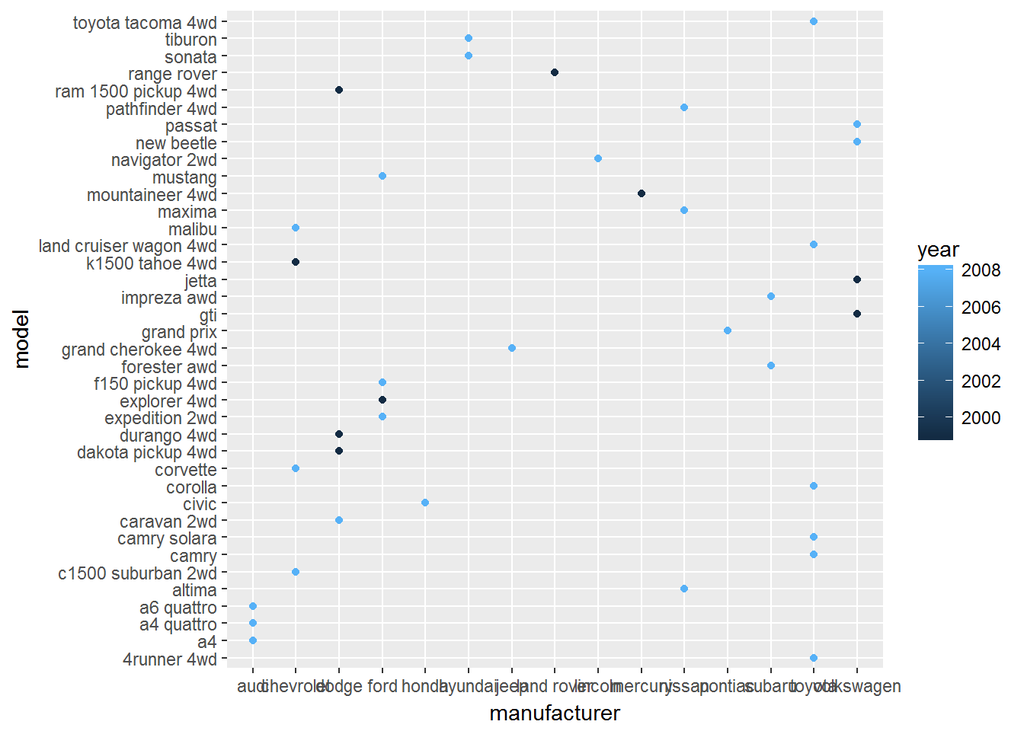

```r
ggplot(data = mpg) + geom_point(mapping = aes(x = manufacturer, y = model, color = year))
```

size = year

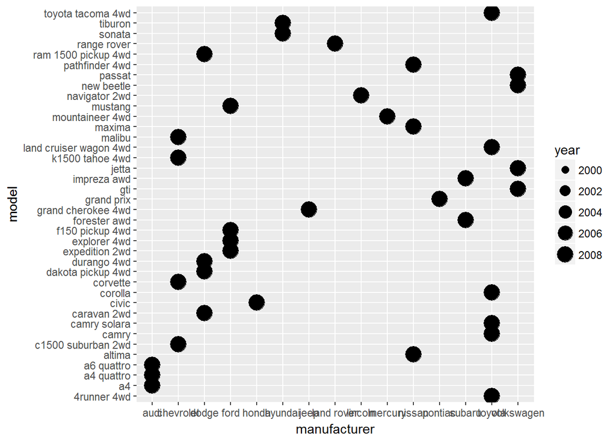

```r
ggplot(data = mpg) + geom_point(mapping = aes(x = manufacturer, y = model, size = year))
```

shape = year

```r
#ggplot(data = mpg) + geom_point(mapping = aes(x = manufacturer, y = model, shape = year))
```

categorical: color = trans

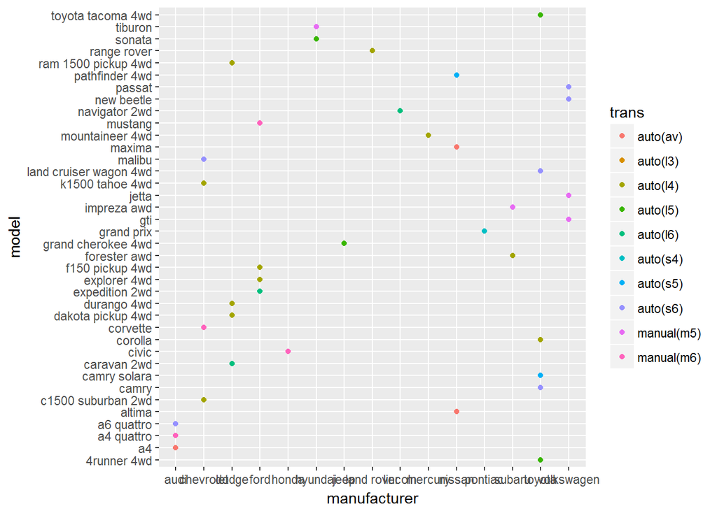

```r
ggplot(data = mpg) + geom_point(mapping = aes(x = manufacturer, y = model, color = trans))
```

# 3.3.1.4

If you map the same variable to multiple aes() functions, it applies both.

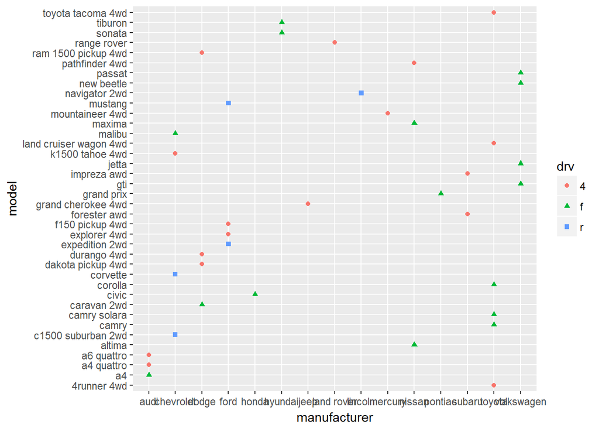

```r
ggplot(data = mpg) + geom_point(mapping = aes(x = manufacturer, y = model, color = drv, shape = drv))
```

# 3.3.1.5

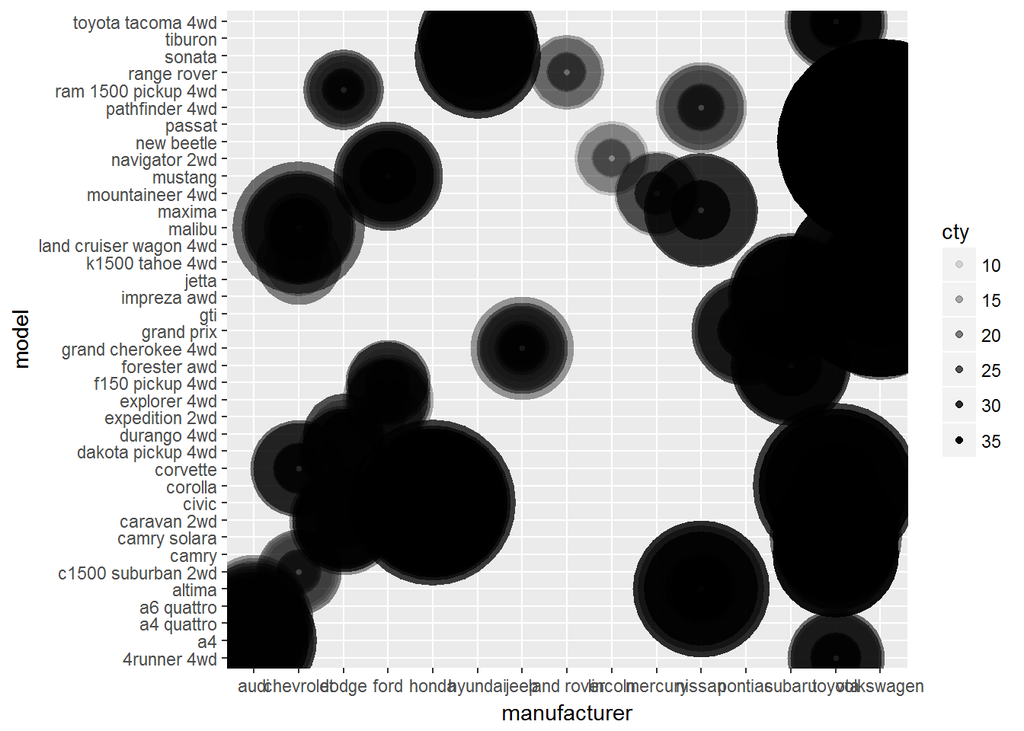

```r
ggplot(data = mpg) + geom_point(mapping = aes(x = manufacturer, y = model, alpha = cty, stroke = cty))
```